# 重賞レース予測レポート【毎時自動更新中】

作成日時: 2025/09/14 10:05:22

☞ [マニュアル(pdf)](https://ryutoro-galois.github.io/keiba-predictor/manual/manual.pdf)

☞ 過去5年の同一レース結果: [2024年](https://ryutoro-galois.github.io/keiba-predictor/report/PredResult_2024y_raceDate_20240914_20240916.html), [2023年](https://ryutoro-galois.github.io/keiba-predictor/report/PredResult_2023y_raceDate_20230916_20230918.html), [2022年](https://ryutoro-galois.github.io/keiba-predictor/report/PredResult_2022y_raceDate_20220917_20220919.html), [2021年](https://ryutoro-galois.github.io/keiba-predictor/report/PredResult_2021y_raceDate_20210918_20210920.html), [2020年](https://ryutoro-galois.github.io/keiba-predictor/report/PredResult_2020y_raceDate_20200919_20200921.html)

☞ 過去4週間の別レース結果: [1週前(9/6-7)](https://ryutoro-galois.github.io/keiba-predictor/report/PredResult_2025y_raceDate_20250906_20250907.html), [2週前(8/31)](https://ryutoro-galois.github.io/keiba-predictor/report/PredResult_2025y_raceDate_20250831_20250831.html), [3週前(8/24)](https://ryutoro-galois.github.io/keiba-predictor/report/PredResult_2025y_raceDate_20250824_20250824.html), [4週前(8/16-17)](https://ryutoro-galois.github.io/keiba-predictor/report/PredResult_2025y_raceDate_20250816_20250817.html)

☞ netkeiba: [チャレンジカップ(GⅢ)](https://race.netkeiba.com/race/shutuba.html?race_id=202509040311&rf=race_list), [ローズステークス(GⅡ)](https://race.netkeiba.com/race/shutuba.html?race_id=202509040411&rf=race_list), [セントライト記念(GⅡ)](https://race.netkeiba.com/race/shutuba.html?race_id=202506040511&rf=race_list)

## 0. 推し馬予測 (AI予測)

### 【チャレンジカップ(GⅢ) 2025/09/13(土)】

- 本命(◎): 1-3着内確率(勝負強さ)が1位の馬
- 対抗(◯): 1-3着内確率が2-N位(20%程度以上)の中で予測タイムが最も速い馬
- 3番手(▲): 1-3着内確率が2-N位(20%程度以上)のでダークホース確率が最も高い馬
- 穴: ダークホース確率が上位1-M位(40%程度以上)の中で1-3着内確率が最も高い馬

| 推し馬 | 枠番 | 馬番 | 人気 | オッズ | 馬名 | 騎手 | 調教師 | 予測タイム(sec) | 1_順位 | 1-3着内確率(%) | 2_順位 | ﾀﾞｰｸﾎｰｽ確率(%) | 3_順位 |
| --- | --- | --- | --- | --- | --- | --- | --- | --- | --- | --- | --- | --- | --- |
| 本命(◎) | 6 | 11 | 2 | 4.7 | オールナット | Ｊ．モレイラ | 高野友和 | 105.9 | 2 | 47.0 | 1 | 0.7 | 13 |
| 対抗(◯) | 7 | 12 | 1 | 3.1 | グランヴィノス | 川田将雅 | 友道康夫 | 105.9 | 2 | 22.1 | 3 | 0.6 | 14 |
| 3番手(▲) | 7 | 13 | 3 | 5.4 | サブマリーナ | 武豊 | 庄野靖志 | 118.5 | 6 | 23.4 | 2 | 0.5 | 15 |
| 穴 | 3 | 5 | 10 | 22.6 | ヴェルテンベルク | 吉村誠之助 | 宮本博 | 119.9 | 11 | 9.7 | 9 | 67.2 | 1 |

### 【ローズステークス(GⅡ) 2025/09/14(日)】

- 本命(◎): 1-3着内確率(勝負強さ)が1位の馬
- 対抗(◯): 1-3着内確率が2-N位(20%程度以上)の中で予測タイムが最も速い馬
- 3番手(▲): 1-3着内確率が2-N位(20%程度以上)のでダークホース確率が最も高い馬
- 穴: ダークホース確率が上位1-M位(40%程度以上)の中で1-3着内確率が最も高い馬

| 推し馬 | 枠番 | 馬番 | 人気 | オッズ | 馬名 | 騎手 | 調教師 | 予測タイム(sec) | 1_順位 | 1-3着内確率(%) | 2_順位 | ﾀﾞｰｸﾎｰｽ確率(%) | 3_順位 |
| --- | --- | --- | --- | --- | --- | --- | --- | --- | --- | --- | --- | --- | --- |
| 本命(◎) | 4 | 8 | 2 | 6.9 | チェルビアット | Ｃ．ルメール | 高野友和 | 110.1 | 16.0 | 46.0 | 1 | 1.4 | 17 |
| 対抗(◯) | 1 | 1 | 6 | 9.2 | ルージュソリテール | 横山武史 | 藤原英昭 | 109.8 | 7.0 | 37.6 | 4 | 2.4 | 12 |
| 穴 | 6 | 12 | 13 | 62.8 | マトラコーニッシュ | 池添謙一 | 池添学 | 109.6 | 4.5 | 11.5 | 13 | 40.1 | 4 |

### 【セントライト記念(GⅡ) 2025/09/15(月)】

- 本命(◎): 1-3着内確率(勝負強さ)が1位の馬
- 対抗(◯): 1-3着内確率が2-N位(20%程度以上)の中で予測タイムが最も速い馬
- 3番手(▲): 1-3着内確率が2-N位(20%程度以上)のでダークホース確率が最も高い馬
- 穴: ダークホース確率が上位1-M位(40%程度以上)の中で1-3着内確率が最も高い馬

| 推し馬 | 枠番 | 馬番 | 人気 | オッズ | 馬名 | 騎手 | 調教師 | 予測タイム(sec) | 1_順位 | 1-3着内確率(%) | 2_順位 | ﾀﾞｰｸﾎｰｽ確率(%) | 3_順位 |
| --- | --- | --- | --- | --- | --- | --- | --- | --- | --- | --- | --- | --- | --- |
| 本命(◎) | 7 | 9 | 3 | 5.8 | ファイアンクランツ | Ｊ．モレイラ | 堀宣行 | 133.2 | 2 | 47.4 | 1 | 1.3 | 10 |
| 対抗(◯) | 5 | 6 | 1 | 2.9 | ミュージアムマイル | 戸崎圭太 | 高柳大輔 | 131.5 | 1 | 21.7 | 3 | 0.8 | 12 |
| 3番手(▲) | 2 | 2 | 5 | 7.7 | ピックデムッシュ | Ｃ．ルメール | 鹿戸雄一 | 141.0 | 10 | 20.6 | 5 | 1.7 | 8 |
| 穴 | 5 | 5 | 7 | 23.7 | ヤマニンブークリエ | 横山典弘 | 松永幹夫 | 140.8 | 3 | 9.4 | 7 | 55.0 | 4 |

## 1. 予測チャート (タイム/勝負強さ)

### 【チャレンジカップ(GⅢ)】

2025/09/13(土), 09_阪神, 芝右2000m

[interactive chart not shown]

### 【ローズステークス(GⅡ)】

2025/09/14(日), 09_阪神, 芝右外1800m

[interactive chart not shown]

### 【セントライト記念(GⅡ)】

2025/09/15(月), 06_中山, 芝右外2200m

[interactive chart not shown]

## 2. オッズモニタリング (毎時)

### 【チャレンジカップ】

[interactive chart not shown]

### 【ローズステークス】

[interactive chart not shown]

### 【セントライト記念】

[interactive chart not shown]

## 3. 出馬表

### 【チャレンジカップ 2025/09/13(土) 】

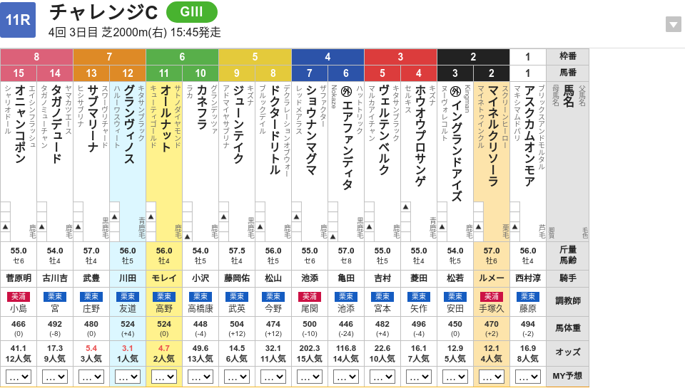

### 【ローズステークス 2025/09/14(日) 】

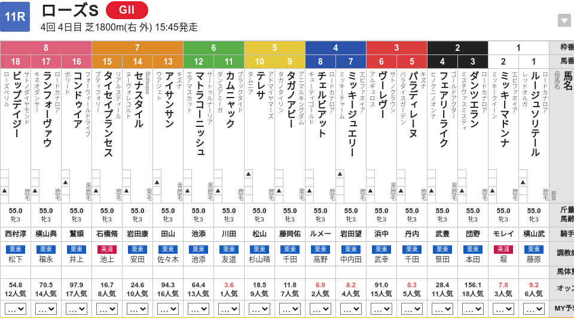

### 【セントライト記念 2025/09/15(月) 】

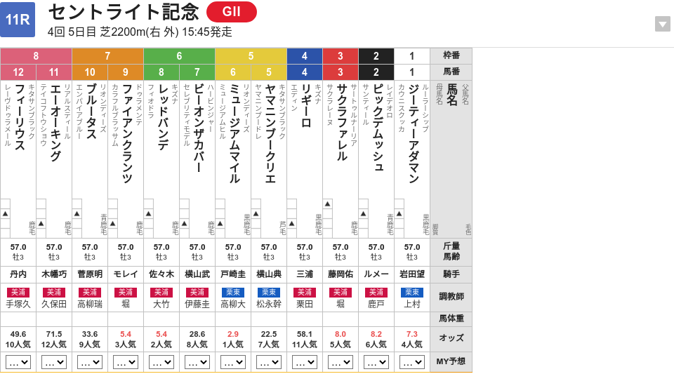

## 4. 単勝予測結果

### 【チャレンジカップ(GⅢ) 2025/09/13(土)】

| 枠番 | 馬番 | 人気 | オッズ | 馬名 | 騎手 | 調教師 | 予測タイム(sec) | 1_順位 | 1-3着内確率(%) | 2_順位 | ﾀﾞｰｸﾎｰｽ確率(%) | 3_順位 |
| --- | --- | --- | --- | --- | --- | --- | --- | --- | --- | --- | --- | --- |
| 1 | 1 | 8 | 16.9 | アスクカムオンモア | 西村淳也 | 藤原英昭 | 120.0 | 12 | 12.8 | 8 | 1.7 | 10 |
| 2 | 2 | 4 | 12.1 | マイネルクリソーラ | Ｃ．ルメール | 手塚貴久 | 122.1 | 13 | 18.0 | 4 | 1.6 | 11 |
| 2 | 3 | 5 | 12.9 | イングランドアイズ | 松若風馬 | 安田翔伍 | 119.6 | 9 | 13.2 | 6 | 1.5 | 12 |
| 3 | 4 | 7 | 16.1 | ホウオウプロサンゲ | 菱田裕二 | 矢作芳人 | 118.6 | 7 | 12.8 | 7 | 1.8 | 9 |
| 3 | 5 | 10 | 22.6 | ヴェルテンベルク | 吉村誠之助 | 宮本博 | 119.9 | 11 | 9.7 | 9 | 67.2 | 1 |
| 4 | 6 | 14 | 116.8 | エアファンディタ | 亀田温心 | 池添学 | 112.5 | 4 | 6.1 | 12 | 18.6 | 5 |
| 4 | 7 | 15 | 202.3 | ショウナンマグマ | 池添謙一 | 尾関知人 | 122.8 | 14 | 2.3 | 14 | 10.7 | 7 |
| 5 | 8 | 11 | 32.1 | ドクタードリトル | 松山弘平 | 今野貞一 | 119.5 | 8 | 5.0 | 13 | 41.7 | 3 |
| 5 | 9 | 6 | 14.5 | ジューンテイク | 藤岡佑介 | 武英智 | 116.8 | 5 | 16.3 | 5 | 1.9 | 8 |
| 6 | 10 | 13 | 49.6 | カネフラ | 小沢大仁 | 高橋康之 | 123.4 | 15 | 2.0 | 15 | 18.3 | 6 |

[output cut: 5 more lines]

### 【ローズステークス(GⅡ) 2025/09/14(日)】

| 枠番 | 馬番 | 人気 | オッズ | 馬名 | 騎手 | 調教師 | 予測タイム(sec) | 1_順位 | 1-3着内確率(%) | 2_順位 | ﾀﾞｰｸﾎｰｽ確率(%) | 3_順位 |
| --- | --- | --- | --- | --- | --- | --- | --- | --- | --- | --- | --- | --- |
| 1 | 1 | 6 | 9.2 | ルージュソリテール | 横山武史 | 藤原英昭 | 109.8 | 7.0 | 37.6 | 4 | 2.4 | 12 |
| 1 | 2 | 3 | 7.6 | ミッキーマドンナ | Ｊ．モレイラ | 堀宣行 | 109.8 | 9.0 | 40.7 | 2 | 1.6 | 14 |
| 2 | 3 | 18 | 157.2 | ダンツエラン | 団野大成 | 本田優 | 113.9 | 18.0 | 3.4 | 17 | 48.7 | 3 |
| 2 | 4 | 11 | 28.4 | フェアリーライク | 武豊 | 笹田和秀 | 109.9 | 11.0 | 16.3 | 11 | 39.8 | 5 |
| 3 | 5 | 5 | 8.3 | パラディレーヌ | 丹内祐次 | 千田輝彦 | 109.8 | 9.0 | 37.6 | 5 | 1.6 | 15 |
| 3 | 6 | 15 | 90.1 | ヴーレヴー | 浜中俊 | 武幸四郎 | 109.6 | 2.0 | 12.7 | 12 | 39.1 | 6 |
| 4 | 7 | 4 | 8.2 | ミッキージュエリー | 岩田望来 | 中内田充正 | 109.8 | 9.0 | 38.0 | 3 | 1.5 | 16 |
| 4 | 8 | 2 | 6.9 | チェルビアット | Ｃ．ルメール | 高野友和 | 110.1 | 16.0 | 46.0 | 1 | 1.4 | 17 |
| 5 | 9 | 7 | 11.7 | タガノアビー | 藤岡佑介 | 千田輝彦 | 109.9 | 12.0 | 32.6 | 6 | 2.4 | 10 |
| 5 | 10 | 9 | 18.8 | テレサ | 松山弘平 | 杉山晴紀 | 109.9 | 14.0 | 21.2 | 8 | 2.4 | 13 |

[output cut: 8 more lines]

### 【セントライト記念(GⅡ) 2025/09/15(月)】

| 枠番 | 馬番 | 人気 | オッズ | 馬名 | 騎手 | 調教師 | 予測タイム(sec) | 1_順位 | 1-3着内確率(%) | 2_順位 | ﾀﾞｰｸﾎｰｽ確率(%) | 3_順位 |
| --- | --- | --- | --- | --- | --- | --- | --- | --- | --- | --- | --- | --- |
| 1 | 1 | 4 | 6.9 | ジーティーアダマン | 岩田望来 | 上村洋行 | 141.0 | 10 | 21.2 | 4 | 1.6 | 9 |
| 2 | 2 | 5 | 7.7 | ピックデムッシュ | Ｃ．ルメール | 鹿戸雄一 | 141.0 | 10 | 20.6 | 5 | 1.7 | 8 |
| 3 | 3 | 6 | 8.1 | サクラファレル | 藤岡佑介 | 堀宣行 | 141.0 | 10 | 18.3 | 6 | 1.7 | 7 |
| 4 | 4 | 11 | 54.5 | リギーロ | 三浦皇成 | 栗田徹 | 140.9 | 6 | 8.9 | 8 | 73.9 | 1 |
| 5 | 5 | 7 | 23.7 | ヤマニンブークリエ | 横山典弘 | 松永幹夫 | 140.8 | 3 | 9.4 | 7 | 55.0 | 4 |
| 5 | 6 | 1 | 2.9 | ミュージアムマイル | 戸崎圭太 | 高柳大輔 | 131.5 | 1 | 21.7 | 3 | 0.8 | 12 |
| 6 | 7 | 8 | 30.2 | ビーオンザカバー | 横山武史 | 伊藤圭三 | 140.9 | 6 | 8.6 | 9 | 44.9 | 6 |
| 6 | 8 | 2 | 5.3 | レッドバンデ | 佐々木大輔 | 大竹正博 | 141.1 | 12 | 22.6 | 2 | 1.0 | 11 |
| 7 | 9 | 3 | 5.8 | ファイアンクランツ | Ｊ．モレイラ | 堀宣行 | 133.2 | 2 | 47.4 | 1 | 1.3 | 10 |
| 7 | 10 | 9 | 32.6 | ブルータス | 菅原明良 | 高柳瑞樹 | 140.9 | 6 | 8.3 | 12 | 48.2 | 5 |

[output cut: 2 more lines]

## 5. 人気と着順の乖離率推移

### 【チャレンジカップ_1990y_2019y】

[interactive chart not shown]

### 【ローズステークス_1990y_2019y】

[interactive chart not shown]

### 【セントライト記念_1990y_2019y】

[interactive chart not shown]

### 【チャレンジカップ_1990y_2019y】

| No | 開催年 | 不整合率(%) | 頭数 | 人気別着順(1-3位) | 人気別着順(全体) |
| --- | --- | --- | --- | --- | --- |
| 30 | 2019 | 46.0 | 12頭 | 2-8-3 | 2\|8\|3\|11\|10\|5\|6\|7\|1\|4\|12\|9 |
| 29 | 2018 | 47.2 | 12頭 | 2-4-5 | 2\|4\|5\|3\|12\|1\|7\|11\|10\|6\|9\|8 |
| 28 | 2017 | 16.3 | 12頭 | 1-5-2 | 1\|5\|2\|3\|11\|6\|9\|7\|8\|10\|4\|12 |
| 27 | 2016 | 26.6 | 18頭 | 9-5-11 | 9\|5\|11\|1\|2\|6\|14\|7\|3\|8\|4\|17\|10\|16\|13\|15\|18\|12 |
| 26 | 2015 | 12.6 | 18頭 | 1-2-11 | 1\|2\|11\|3\|4\|12\|7\|6\|14\|9\|13\|10\|8\|15\|18\|5\|17\|16 |
| 25 | 2014 | 57.3 | 12頭 | 5-9-2 | 5\|9\|2\|6\|7\|3\|11\|4\|1\|8\|12\|10 |
| 24 | 2013 | 26.6 | 16頭 | 5-1-2 | 5\|1\|2\|14\|6\|8\|11\|15\|4\|3\|10\|7\|9\|13\|16\|12 |
| 23 | 2012 | 43.6 | 16頭 | 3-10-7 | 3\|10\|7\|8\|1\|2\|9\|12\|15\|11\|13\|6\|4\|14\|5\|16 |
| 22 | 2011 | 50.6 | 18頭 | 8-2-6 | 8\|2\|6\|7\|12\|3\|10\|4\|5\|9\|18\|14\|1\|13\|15\|16\|11\|17 |
| 21 | 2010 | 51.5 | 16頭 | 7-4-5 | 7\|4\|5\|2\|6\|8\|9\|13\|15\|1\|12\|14\|16\|11\|10\|3 |

[output cut: 20 more lines]

### 【ローズステークス_1990y_2019y】

| No | 開催年 | 不整合率(%) | 頭数 | 人気別着順(1-3位) | 人気別着順(全体) |
| --- | --- | --- | --- | --- | --- |
| 30 | 2019 | 18.0 | 12頭 | 1-6-2 | 1\|6\|2\|4\|8\|3\|10\|7\|5\|9\|12\|11 |
| 29 | 2018 | 42.2 | 15頭 | 5-2-13 | 5\|2\|13\|8\|6\|1\|4\|11\|3\|14\|10\|9\|12\|15\|7 |
| 28 | 2017 | 47.4 | 18頭 | 8-6-3 | 8\|6\|3\|5\|12\|1\|2\|17\|4\|13\|15\|7\|11\|9\|18\|10\|14\|16 |
| 27 | 2016 | 39.5 | 15頭 | 1-11-6 | 1\|11\|6\|8\|3\|10\|5\|4\|12\|15\|2\|14\|7\|9\|13 |
| 26 | 2015 | 12.9 | 17頭 | 7-1-2 | 7\|1\|2\|3\|5\|4\|6\|9\|15\|13\|14\|12\|17\|8\|10\|11\|16 |
| 25 | 2014 | 38.7 | 17頭 | 2-15-9 | 2\|15\|9\|6\|4\|1\|7\|13\|3\|8\|12\|16\|14\|10\|5\|11\|17 |
| 24 | 2013 | 46.5 | 18頭 | 1-9-10 | 1\|9\|10\|4\|8\|5\|16\|7\|13\|18\|6\|11\|3\|2\|15\|17\|14\|12 |
| 23 | 2012 | 5.9 | 10頭 | 1-2-3 | 1\|2\|3\|5\|4\|7\|9\|8\|6\|10 |
| 22 | 2011 | 30.1 | 14頭 | 1-10-7 | 1\|10\|7\|4\|5\|2\|11\|6\|9\|3\|8\|14\|12\|13 |
| 21 | 2010 | 38.4 | 12頭 | 4-6-5 | 4\|6\|5\|1\|8\|11\|2\|3\|10\|7\|12\|9 |

[output cut: 20 more lines]

### 【セントライト記念_1990y_2019y】

| No | 開催年 | 不整合率(%) | 頭数 | 人気別着順(1-3位) | 人気別着順(全体) |
| --- | --- | --- | --- | --- | --- |
| 30 | 2019 | 29.2 | 18頭 | 1-8-3 | 1\|8\|3\|5\|2\|6\|14\|17\|16\|15\|11\|13\|12\|4\|10\|7\|9\|18 |
| 29 | 2018 | 31.4 | 15頭 | 4-1-6 | 4\|1\|6\|2\|10\|14\|5\|15\|12\|9\|13\|7\|3\|8\|11 |
| 28 | 2017 | 24.2 | 15頭 | 2-1-3 | 2\|1\|3\|6\|8\|7\|5\|10\|4\|13\|9\|12\|11\|15\|14 |
| 27 | 2016 | 9.9 | 12頭 | 1-2-3 | 1\|2\|3\|11\|8\|5\|4\|10\|7\|6\|12\|9 |
| 26 | 2015 | 53.1 | 15頭 | 6-9-10 | 6\|9\|10\|14\|3\|5\|1\|7\|12\|2\|15\|13\|8\|11\|4 |
| 25 | 2014 | 27.4 | 18頭 | 1-2-10 | 1\|2\|10\|5\|9\|11\|13\|7\|6\|4\|15\|8\|3\|17\|12\|16\|18\|14 |
| 24 | 2013 | 62.4 | 15頭 | 3-5-6 | 3\|5\|6\|12\|2\|4\|9\|11\|14\|10\|8\|7\|1\|15\|13 |
| 23 | 2012 | 28.2 | 17頭 | 1-14-4 | 1\|14\|4\|5\|8\|6\|11\|9\|2\|10\|3\|7\|13\|12\|15\|16\|17 |
| 22 | 2011 | 40.6 | 17頭 | 6-3-1 | 6\|3\|1\|2\|8\|10\|15\|14\|9\|11\|4\|17\|12\|7\|16\|13\|5 |
| 21 | 2010 | 65.0 | 17頭 | 4-3-2 | 4\|3\|2\|11\|6\|8\|12\|10\|7\|13\|9\|5\|15\|1\|14\|17\|16 |

[output cut: 20 more lines]

## 6. 1-3番人気馬の着順分類予測

### 【チャレンジカップ】

| 分類 | 凡例 | 発生確率(%) | 当該レース | 当該レースランク | 直近1年間 |
| --- | --- | --- | --- | --- | --- |
| 1: 1番人気のみ (1_pop1) | 1 \| * \| * | 17.0 | 1.98 | 1.98 | 0.00 |
| 4: 1,2番人気のみ (4_pop12) | 1 \| 2 \| * | 16.7 | 0.98 | 0.98 | 0.50 |
| 8: 1,2,3番人気すべて着外 (8_darkhorse) | * \| * \| * | 14.5 | 1.01 | 1.01 | 0.00 |
| 5: 1,3番人気のみ (5_pop13) | 1 \| 3 \| * | 13.9 | 2.44 | 2.44 | 0.00 |
| 6: 2,3番人気のみ (6_pop23) | 2 \| 3 \| * | 11.4 | 0.44 | 0.44 | 0.34 |
| 2: 2番人気のみ (2_pop2) | 2 \| * \| * | 9.9 | 0.58 | 0.58 | 0.00 |
| 3: 3番人気のみ (3_pop3) | 3 \| * \| * | 9.3 | 1.63 | 1.63 | 0.28 |
| 7: 1,2,3番人気すべて着内 (7_pop123) | 1 \| 2 \| 3 | 7.2 | 1.26 | 1.26 | 0.00 |

### 【ローズステークス】

| 分類 | 凡例 | 発生確率(%) | 当該レース | 当該レースランク | 直近1年間 |
| --- | --- | --- | --- | --- | --- |
| 1: 1番人気のみ (1_pop1) | 1 \| * \| * | 17.0 | 0.85 | 0.99 | 0.00 |
| 4: 1,2番人気のみ (4_pop12) | 1 \| 2 \| * | 16.7 | 0.45 | 0.65 | 0.33 |
| 8: 1,2,3番人気すべて着外 (8_darkhorse) | * \| * \| * | 14.5 | 1.69 | 1.69 | 0.00 |
| 5: 1,3番人気のみ (5_pop13) | 1 \| 3 \| * | 13.9 | 2.44 | 1.96 | 0.00 |
| 6: 2,3番人気のみ (6_pop23) | 2 \| 3 \| * | 11.4 | 2.00 | 2.00 | 0.00 |
| 2: 2番人気のみ (2_pop2) | 2 \| * \| * | 9.9 | 0.87 | 1.15 | 0.00 |
| 3: 3番人気のみ (3_pop3) | 3 \| * \| * | 9.3 | 3.21 | 0.43 | 0.19 |
| 7: 1,2,3番人気すべて着内 (7_pop123) | 1 \| 2 \| 3 | 7.2 | 0.84 | 1.26 | 0.00 |

### 【セントライト記念】

| 分類 | 凡例 | 発生確率(%) | 当該レース | 当該レースランク | 直近1年間 |
| --- | --- | --- | --- | --- | --- |
| 4: 1,2番人気のみ (4_pop12) | 1 \| 2 \| * | 19.5 | 1.36 | 0.76 | 0.39 |
| 1: 1番人気のみ (1_pop1) | 1 \| * \| * | 17.7 | 1.24 | 1.04 | 0.00 |
| 5: 1,3番人気のみ (5_pop13) | 1 \| 3 \| * | 14.0 | 1.63 | 1.97 | 0.00 |
| 8: 1,2,3番人気すべて着外 (8_darkhorse) | * \| * \| * | 13.2 | 1.53 | 1.53 | 0.00 |
| 2: 2番人気のみ (2_pop2) | 2 \| * \| * | 10.1 | 1.77 | 1.17 | 0.00 |
| 3: 3番人気のみ (3_pop3) | 3 \| * \| * | 9.4 | 0.23 | 0.44 | 0.19 |
| 6: 2,3番人気のみ (6_pop23) | 2 \| 3 \| * | 8.8 | 1.54 | 1.54 | 0.00 |
| 7: 1,2,3番人気すべて着内 (7_pop123) | 1 \| 2 \| 3 | 7.2 | 2.48 | 1.26 | 0.00 |

## 7. 3連複予測結果

### 【チャレンジカップ(GⅢ) 2025/09/13(土)】

| 分類 | 馬番 | 枠番 | 人気 | 平均予測タイム(sec) | 1-3着内確率(%) | ﾀﾞｰｸﾎｰｽ確率(%) | 馬名 | 騎手 | 調教師 |
| --- | --- | --- | --- | --- | --- | --- | --- | --- | --- |
| 7: 1,2,3番人気すべて着内 (7_pop123) | 12-11-13 | 7-6-7 | 1-2-3 | 110.10 | 2.43 | 0.00 | グランヴィノス \| オールナット \| サブマリーナ | 川田将雅 \| Ｊ．モレイラ \| 武豊 | 友道康夫 \| 高野友和 \| 庄野靖志 |
| 6: 2,3番人気のみ (6_pop23) | 11-13-2 | 6-7-2 | 2-3-4 | 115.50 | 1.98 | 0.00 | オールナット \| サブマリーナ \| マイネルクリソーラ | Ｊ．モレイラ \| 武豊 \| Ｃ．ルメール | 高野友和 \| 庄野靖志 \| 手塚貴久 |
| 4: 1,2番人気のみ (4_pop12) | 12-11-2 | 7-6-2 | 1-2-4 | 111.30 | 1.87 | 0.00 | グランヴィノス \| オールナット \| マイネルクリソーラ | 川田将雅 \| Ｊ．モレイラ \| Ｃ．ルメール | 友道康夫 \| 高野友和 \| 手塚貴久 |
| 6: 2,3番人気のみ (6_pop23) | 11-13-9 | 6-7-5 | 2-3-6 | 113.73 | 1.79 | 0.00 | オールナット \| サブマリーナ \| ジューンテイク | Ｊ．モレイラ \| 武豊 \| 藤岡佑介 | 高野友和 \| 庄野靖志 \| 武英智 |
| 4: 1,2番人気のみ (4_pop12) | 12-11-9 | 7-6-5 | 1-2-6 | 109.53 | 1.69 | 0.00 | グランヴィノス \| オールナット \| ジューンテイク | 川田将雅 \| Ｊ．モレイラ \| 藤岡佑介 | 友道康夫 \| 高野友和 \| 武英智 |
| 6: 2,3番人気のみ (6_pop23) | 11-13-3 | 6-7-2 | 2-3-5 | 114.67 | 1.45 | 0.00 | オールナット \| サブマリーナ \| イングランドアイズ | Ｊ．モレイラ \| 武豊 \| 松若風馬 | 高野友和 \| 庄野靖志 \| 安田翔伍 |
| 6: 2,3番人気のみ (6_pop23) | 11-13-4 | 6-7-3 | 2-3-7 | 114.33 | 1.41 | 0.00 | オールナット \| サブマリーナ \| ホウオウプロサンゲ | Ｊ．モレイラ \| 武豊 \| 菱田裕二 | 高野友和 \| 庄野靖志 \| 矢作芳人 |
| 6: 2,3番人気のみ (6_pop23) | 11-13-1 | 6-7-1 | 2-3-8 | 114.80 | 1.40 | 0.00 | オールナット \| サブマリーナ \| アスクカムオンモア | Ｊ．モレイラ \| 武豊 \| 西村淳也 | 高野友和 \| 庄野靖志 \| 藤原英昭 |
| 2: 2番人気のみ (2_pop2) | 11-2-9 | 6-2-5 | 2-4-6 | 114.93 | 1.38 | 0.00 | オールナット \| マイネルクリソーラ \| ジューンテイク | Ｊ．モレイラ \| Ｃ．ルメール \| 藤岡佑介 | 高野友和 \| 手塚貴久 \| 武英智 |
| 4: 1,2番人気のみ (4_pop12) | 12-11-3 | 7-6-2 | 1-2-5 | 110.47 | 1.38 | 0.00 | グランヴィノス \| オールナット \| イングランドアイズ | 川田将雅 \| Ｊ．モレイラ \| 松若風馬 | 友道康夫 \| 高野友和 \| 安田翔伍 |

[output cut: 445 more lines]

### 【ローズステークス(GⅡ) 2025/09/14(日)】

| 分類 | 馬番 | 枠番 | 人気 | 平均予測タイム(sec) | 1-3着内確率(%) | ﾀﾞｰｸﾎｰｽ確率(%) | 馬名 | 騎手 | 調教師 |
| --- | --- | --- | --- | --- | --- | --- | --- | --- | --- |
| 6: 2,3番人気のみ (6_pop23) | 8-2-7 | 4-1-4 | 2-3-4 | 109.90 | 7.10 | 0.00 | チェルビアット \| ミッキーマドンナ \| ミッキージュエリー | Ｃ．ルメール \| Ｊ．モレイラ \| 岩田望来 | 高野友和 \| 堀宣行 \| 中内田充正 |
| 6: 2,3番人気のみ (6_pop23) | 8-2-1 | 4-1-1 | 2-3-6 | 109.90 | 7.04 | 0.00 | チェルビアット \| ミッキーマドンナ \| ルージュソリテール | Ｃ．ルメール \| Ｊ．モレイラ \| 横山武史 | 高野友和 \| 堀宣行 \| 藤原英昭 |
| 6: 2,3番人気のみ (6_pop23) | 8-2-5 | 4-1-3 | 2-3-5 | 109.90 | 7.04 | 0.00 | チェルビアット \| ミッキーマドンナ \| パラディレーヌ | Ｃ．ルメール \| Ｊ．モレイラ \| 丹内祐次 | 高野友和 \| 堀宣行 \| 千田輝彦 |
| 2: 2番人気のみ (2_pop2) | 8-7-1 | 4-4-1 | 2-4-6 | 109.90 | 6.57 | 0.00 | チェルビアット \| ミッキージュエリー \| ルージュソリテール | Ｃ．ルメール \| 岩田望来 \| 横山武史 | 高野友和 \| 中内田充正 \| 藤原英昭 |
| 2: 2番人気のみ (2_pop2) | 8-7-5 | 4-4-3 | 2-4-5 | 109.90 | 6.56 | 0.00 | チェルビアット \| ミッキージュエリー \| パラディレーヌ | Ｃ．ルメール \| 岩田望来 \| 丹内祐次 | 高野友和 \| 中内田充正 \| 千田輝彦 |
| 2: 2番人気のみ (2_pop2) | 8-5-1 | 4-3-1 | 2-5-6 | 109.90 | 6.50 | 0.00 | チェルビアット \| パラディレーヌ \| ルージュソリテール | Ｃ．ルメール \| 丹内祐次 \| 横山武史 | 高野友和 \| 千田輝彦 \| 藤原英昭 |
| 6: 2,3番人気のみ (6_pop23) | 8-2-9 | 4-1-5 | 2-3-7 | 109.93 | 6.11 | 0.00 | チェルビアット \| ミッキーマドンナ \| タガノアビー | Ｃ．ルメール \| Ｊ．モレイラ \| 藤岡佑介 | 高野友和 \| 堀宣行 \| 千田輝彦 |
| 3: 3番人気のみ (3_pop3) | 2-7-1 | 1-4-1 | 3-4-6 | 109.80 | 5.82 | 0.00 | ミッキーマドンナ \| ミッキージュエリー \| ルージュソリテール | Ｊ．モレイラ \| 岩田望来 \| 横山武史 | 堀宣行 \| 中内田充正 \| 藤原英昭 |
| 3: 3番人気のみ (3_pop3) | 2-7-5 | 1-4-3 | 3-4-5 | 109.80 | 5.82 | 0.00 | ミッキーマドンナ \| ミッキージュエリー \| パラディレーヌ | Ｊ．モレイラ \| 岩田望来 \| 丹内祐次 | 堀宣行 \| 中内田充正 \| 千田輝彦 |
| 3: 3番人気のみ (3_pop3) | 2-5-1 | 1-3-1 | 3-5-6 | 109.80 | 5.76 | 0.00 | ミッキーマドンナ \| パラディレーヌ \| ルージュソリテール | Ｊ．モレイラ \| 丹内祐次 \| 横山武史 | 堀宣行 \| 千田輝彦 \| 藤原英昭 |

[output cut: 806 more lines]

### 【セントライト記念(GⅡ) 2025/09/15(月)】

| 分類 | 馬番 | 枠番 | 人気 | 平均予測タイム(sec) | 1-3着内確率(%) | ﾀﾞｰｸﾎｰｽ確率(%) | 馬名 | 騎手 | 調教師 |
| --- | --- | --- | --- | --- | --- | --- | --- | --- | --- |
| 7: 1,2,3番人気すべて着内 (7_pop123) | 6-8-9 | 5-6-7 | 1-2-3 | 135.27 | 2.32 | 0.00 | ミュージアムマイル \| レッドバンデ \| ファイアンクランツ | 戸崎圭太 \| 佐々木大輔 \| Ｊ．モレイラ | 高柳大輔 \| 大竹正博 \| 堀宣行 |
| 6: 2,3番人気のみ (6_pop23) | 8-9-1 | 6-7-1 | 2-3-4 | 138.43 | 2.27 | 0.00 | レッドバンデ \| ファイアンクランツ \| ジーティーアダマン | 佐々木大輔 \| Ｊ．モレイラ \| 岩田望来 | 大竹正博 \| 堀宣行 \| 上村洋行 |
| 6: 2,3番人気のみ (6_pop23) | 8-9-2 | 6-7-2 | 2-3-5 | 138.43 | 2.21 | 0.00 | レッドバンデ \| ファイアンクランツ \| ピックデムッシュ | 佐々木大輔 \| Ｊ．モレイラ \| Ｃ．ルメール | 大竹正博 \| 堀宣行 \| 鹿戸雄一 |
| 5: 1,3番人気のみ (5_pop13) | 6-9-1 | 5-7-1 | 1-3-4 | 135.23 | 2.18 | 0.00 | ミュージアムマイル \| ファイアンクランツ \| ジーティーアダマン | 戸崎圭太 \| Ｊ．モレイラ \| 岩田望来 | 高柳大輔 \| 堀宣行 \| 上村洋行 |
| 5: 1,3番人気のみ (5_pop13) | 6-9-2 | 5-7-2 | 1-3-5 | 135.23 | 2.12 | 0.00 | ミュージアムマイル \| ファイアンクランツ \| ピックデムッシュ | 戸崎圭太 \| Ｊ．モレイラ \| Ｃ．ルメール | 高柳大輔 \| 堀宣行 \| 鹿戸雄一 |
| 3: 3番人気のみ (3_pop3) | 9-1-2 | 7-1-2 | 3-4-5 | 138.40 | 2.07 | 0.00 | ファイアンクランツ \| ジーティーアダマン \| ピックデムッシュ | Ｊ．モレイラ \| 岩田望来 \| Ｃ．ルメール | 堀宣行 \| 上村洋行 \| 鹿戸雄一 |
| 6: 2,3番人気のみ (6_pop23) | 8-9-3 | 6-7-3 | 2-3-6 | 138.43 | 1.96 | 0.00 | レッドバンデ \| ファイアンクランツ \| サクラファレル | 佐々木大輔 \| Ｊ．モレイラ \| 藤岡佑介 | 大竹正博 \| 堀宣行 \| 堀宣行 |
| 5: 1,3番人気のみ (5_pop13) | 6-9-3 | 5-7-3 | 1-3-6 | 135.23 | 1.88 | 0.00 | ミュージアムマイル \| ファイアンクランツ \| サクラファレル | 戸崎圭太 \| Ｊ．モレイラ \| 藤岡佑介 | 高柳大輔 \| 堀宣行 \| 堀宣行 |
| 3: 3番人気のみ (3_pop3) | 9-1-3 | 7-1-3 | 3-4-6 | 138.40 | 1.84 | 0.00 | ファイアンクランツ \| ジーティーアダマン \| サクラファレル | Ｊ．モレイラ \| 岩田望来 \| 藤岡佑介 | 堀宣行 \| 上村洋行 \| 堀宣行 |
| 3: 3番人気のみ (3_pop3) | 9-2-3 | 7-2-3 | 3-5-6 | 138.40 | 1.79 | 0.00 | ファイアンクランツ \| ピックデムッシュ \| サクラファレル | Ｊ．モレイラ \| Ｃ．ルメール \| 藤岡佑介 | 堀宣行 \| 鹿戸雄一 \| 堀宣行 |

[output cut: 210 more lines]

## 8. 直近の全レース情報

[output not shown]

[output cut: 2 more lines]